# vizcovidfr, a Covid-19 analysis package

25/04/2021

## Our goals

- Analyze the spreading of the Covid-19 disease in France.
- Produce various charts to illustrate how the Covid-19 affects population.
- Predict how the Covid-19 will evolve in the future.
- Create a simple visualization tool as interactive as possible and easy to use for anyone.

## Data (part 1/3)

- All the datasets that we used are taken from https://www.data.gouv.fr/fr/pages/donnees-coronavirus.
- Data is collected almost every day per region / department for different variables such as hospitalization or death for example.
- Here is a summary table of every dataset used.

## Data (part 2/3)

| dataset | desciption |
| --- | --- |
| `chiffres-cles` | hospitalization, intensive care, death, by regions and departments |
| `chiffres-fr` | cases, hospitalization, intensive care, death for the whole France |
| `classe_age` | hospitalization, intensive care, death, by age range and region |
| `covid-19-france-vaccinations-age-dep` | vaccine administration by age |
| `stocks-es-national` | vaccine type in storage |
| `transfer.csv` | patient transfers |

## Data (part 3/3)

| dataset | desciption |
| --- | --- |
| `posquotreg` | positivity and tests by sex and age for regions (daily) |
| `posquotfr` | positivity and tests by sex and age for the whole France (daily) |
| `poshebreg` | positivity and tests by sex and age for regions (weekly) |
| `poshebfr` | positivity and tests by sex and age for the whole France (weekly) |
| `incquotreg` | incidence rate by sex and age for regions |
| `incquotfr` | incidence rate by sex and age for the whole France |

## Module structure (part 1/3)

```
vizcovidfr
|   .github/workflows
|   beamer
|   doc
│   report
|   vizcovidfr
|   .gitignore
|   README.md
|   requirements.txt
└── setup.py
```

## Module structure (part 2/3)

```
vizcovidfr
|   ...
│
└───vizcovidfr
│   │   barplots
│   │   data
|   |   heatmap
|   |   line_charts
|   |   loads
|   |   maps
|   |   pie_charts
|   |   prediction
|   |   preprocesses
|   |   regression
|   |   sparse
|   |   tests
|   |   README.md
|   └── __init__.py
```

## Module structure (part 3/3)

```
vizcovidfr
|   ...
│
└───vizcovidfr
│   │   ...
|   |
│   └───tests
│       │   __init__.py
│       └── test_vizcovidfr.py
|
│
└───...
```

## `test_vizcovidfr.py`

[output not shown]

## Workflow

- Each contributor created a class to load the dataset he used.
- Each contributor put as many functions as possible in preprocess to have a clear code, which allowed others to use them.
- Each contributor worked on his branch to avoid conflicts.
- Each contributor created his own modules, with its documentation and their unit tests associated.

## Regression and prediction (part 1/8)

- Because we had data relative to the time, we wanted to predict the evolution of Covid-19.
- Here is an example of scatter plot.

[figure not shown]

## Regression and prediction (part 2/8)

- Linear regression is not adapted to data.
- How to make prediction then ?
- \(\implies\) Polynomial regression with poly_fit function
- poly_fit can make \(7 \times 18 = 126\) polynomial regression.
- poly_fit minimizes the mean squared error to fit as good as it can.

## Regression and prediction (part 3/8)

Pros and cons :

- Curve predicted fits well with the data.
- Regression has a good R2 (lots of models have more than \(90 \%\)).
- Good prediction of foreseeable future.
- Problem : impossible to predict in a far future

## Regression and prediction (part 4/8)

[figure not shown]

## Regression and prediction (part 5/8)

Prediction with predict_curve for 2021-04-30 (with data until 2021-04-23) :

[figure not shown]

## Regression and prediction (part 6/8)

- predict_value gives the estimated number for the given date.
- Number of hospitalization in Île-de-France estimated on 2021-04-30 : 16 376

## Regression and prediction (part 7/8)

Prediction with predict_curve for 2021-06-30 (with data until 2021-04-23) :

[figure not shown]

## Regression and prediction (part 8/8)

Advice :

- Use first scatter_reg to see the scatter plot of the given variable for the given region.
- Then use poly_fit function to see how the model fits with data.
- Then use predict_curve to check if the predicted curve is going to infinite or not.
- If predicted curve looks good, then use predict_value to get the value you were looking for.

## Time and memory (part 1/4)

- Each function displays its execution time and they’re all calculated on the same machine.
- Proportionality between dataset size and execution time (the bigger the dataset is, the longer it will be loaded).

## Time/Memory (part 2/4)

| Function | Execution time(s) | Size of the loaded |
| --- | --- | --- |
| vacmap | 74.86038 s. | 12.0MB |
| piechart | from 2.62365 s. to 69.43795 s. | from 6.5MB to 12.0MB |
| viz2Dmap | 21.74077 s. | 6.79MB |
| viz3Dmap | 19.54393 s. | 6.79MB |
| transfer_map | 1.14778 s. | 1.79kB |
| sparse_graph | 0.50041 s. | 1.79kB |
| sparse_matrix | 0.43385 s. | 1.79kB |

## Time/Memory (part 3/4)

| Function | Execution time(s) | Size of the loaded |
| --- | --- | --- |
| regression.R2 | 2.04217 s. | 3.2MB |
| regression.poly_fit | 2.34914 s. | 3.2MB |
| regression.scatter_reg | 1.92033 s. | 3.2MB |
| vacdoses | 0.76860 s. | 2kB |
| vactypedoses | 0.42227 s. | 2kB |
| predict_curve | 2.69524 s. | 3.2MB |
| predict_value | 2.12597 s. | 3.2MB |

## Time/Memory (part 4/4)

| Function | Execution time(s) | Size of the loaded |
| --- | --- | --- |
| bar_age | 1.41214 s. | 3.2MB |
| bar_reg | 1.55690 s. | 3.2MB |
| compareMF | from 0.52738 s. to 2.04961 s. | from 228KB to 3.6MB |
| keytimeseries | from 0.67941 s. to 3.18099 s. | from 25KB to 6.5MB |
| heatmap_age | form 0.53875 s. to 2.09932 s. | from 3.3KB to 34KB |
| heatmap_reg_age | from 0.67732 s. to 1.75079 s. | from 491KB to 3.3KB |
| heatmap_reg_day | from 0.69503 s. to 1.66679 s. | from 401KB to 3.3KB |

## Conclusion / Doorway / Examples

- Watch the documentation to get thorough information about vizcovidfr’s functions.
- Here are some examples taken from our notebook (in ‘report’) to inspire you !

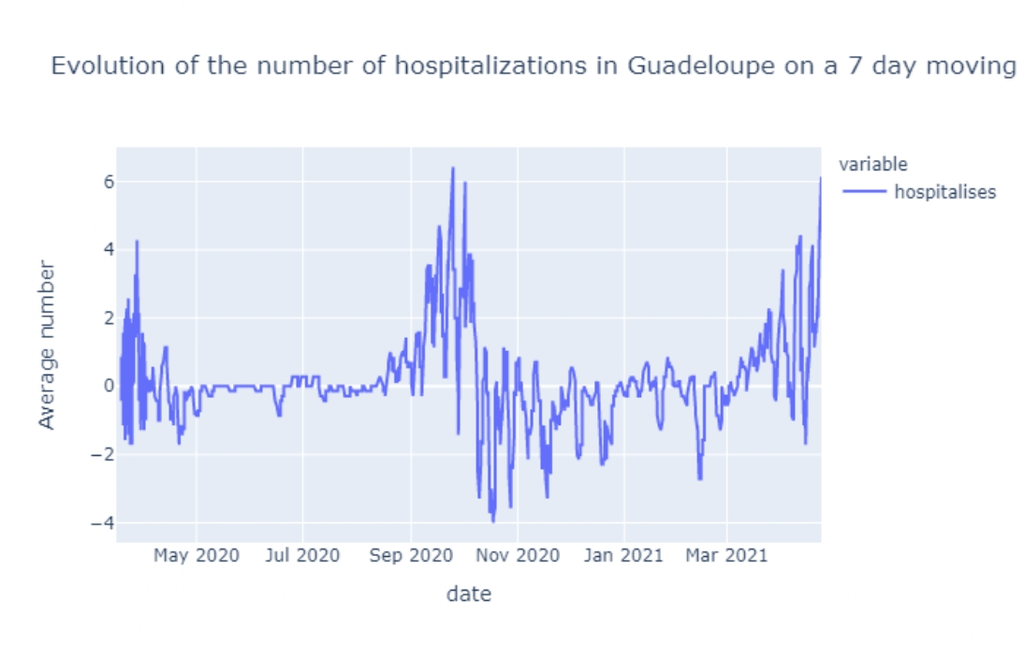

## Conclusion / Doorway / Examples

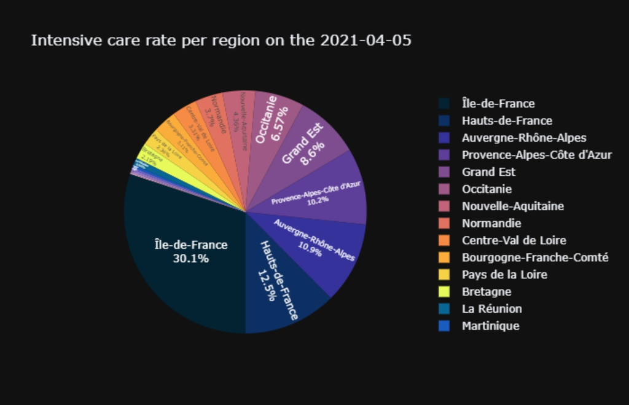

## Conclusion / Doorway / Examples

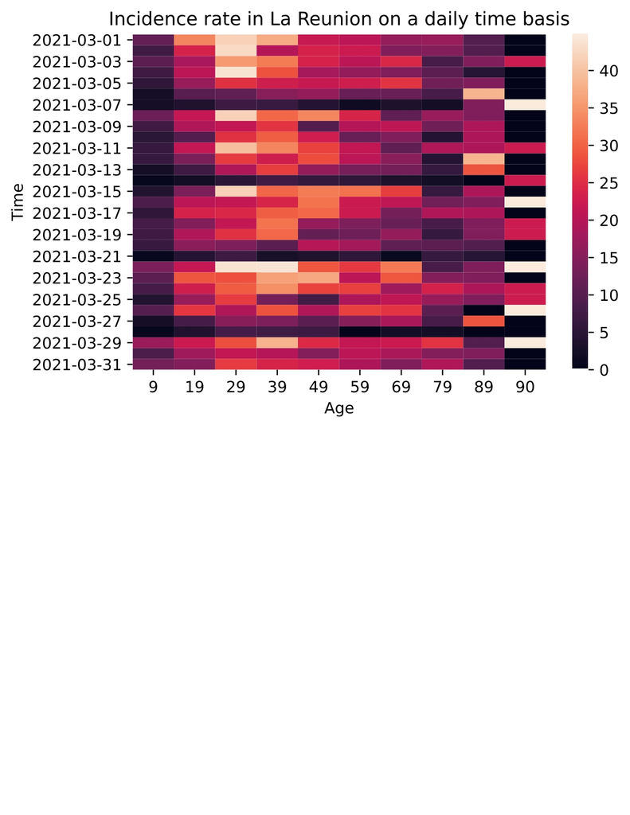

## Conclusion / Doorway / Examples

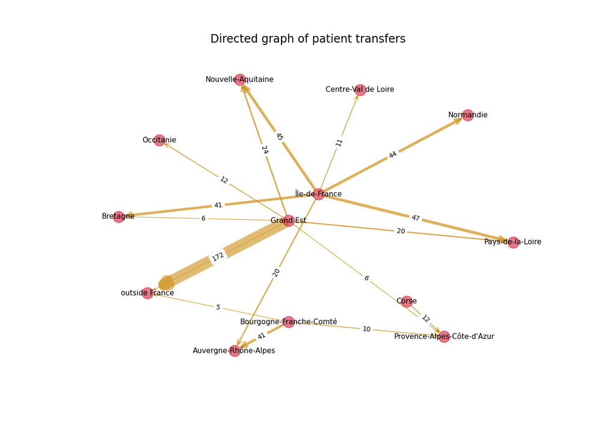